# Laboration 1

Förnamn Efternamn

2024-11-23

```
## ✖ purrr::%||%()   masks base::%||%()
```

# Utanför redovisningen / Introduktion till deskriptiv statistik

I staden Grötköping mättes kroppslängden på 11 av stadens invånare och resultaten (i cm) blev

```r
x <- c(174.6, 173.2, 189.6, 167.7, 179.2, 179.6, 170.5, 168.5, 185.3, 164.1, 178.4)
```

Vi undersök vårt stickprov med några enkla beskrivande mått

```r
print(mean(x)) # Medelvärde
```

```
## [1] 175.5182
```

```r
print(var(x)) # (Stickprovs)varians
```

```
## [1] 60.46564
```

```r
print(sd(x)) # (Stickprovs)standardavvikelse
```

```
## [1] 7.775965
```

```r
print(summary(x)) # Minimum, maximum, median, kvartiler
```

```
##    Min. 1st Qu.  Median    Mean 3rd Qu.    Max.
##   164.1   169.5   174.6   175.5   179.4   189.6
```

Ett träd-blad-diagram:

```r
stem(x)
```

```
##
##   The decimal point is 1 digit(s) to the right of the |
##
##   16 | 489
##   17 | 13589
##   18 | 05
##   19 | 0
```

Ett histogram för datat:

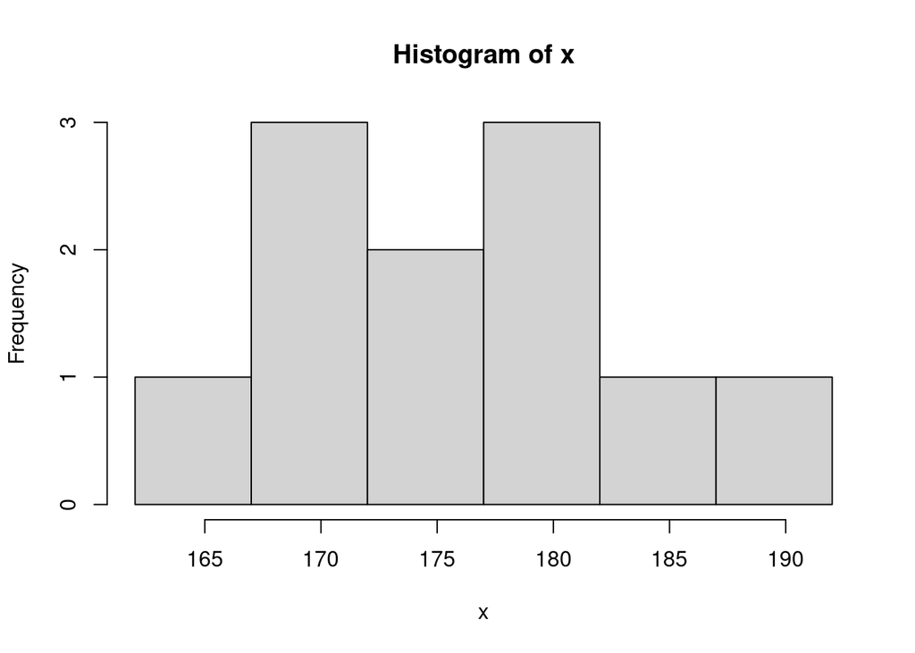

```r
hist(x, breaks = seq(from = 162, to = 192, by = 5))
```

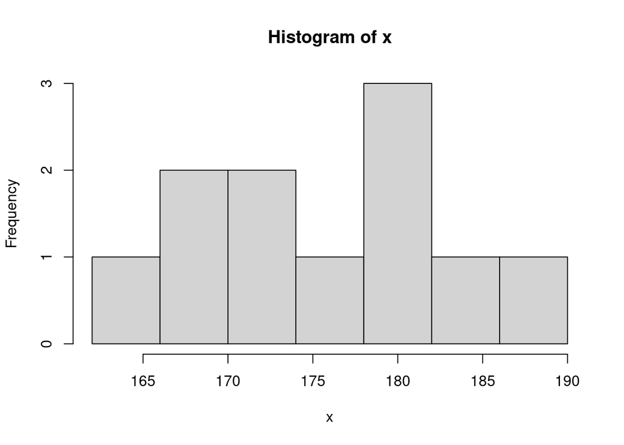

```r
hist(x, breaks = seq(from = 162, to = 190, by = 4))
```

En boxplot för datat:

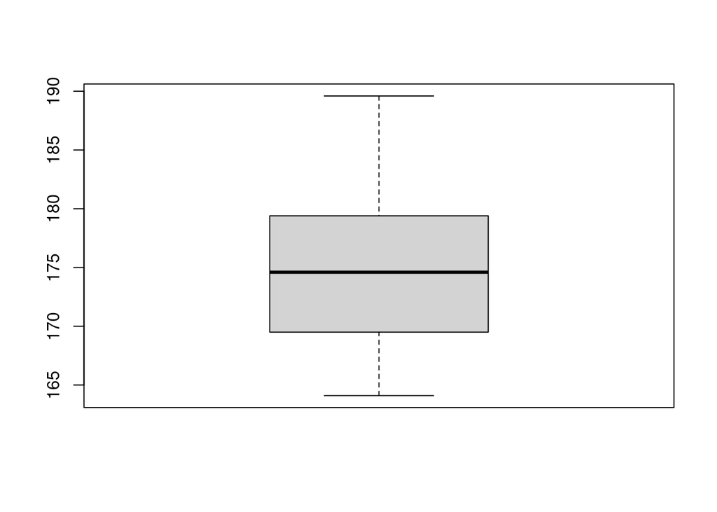

```r
boxplot(x)
```

Normalfördelningsplot:

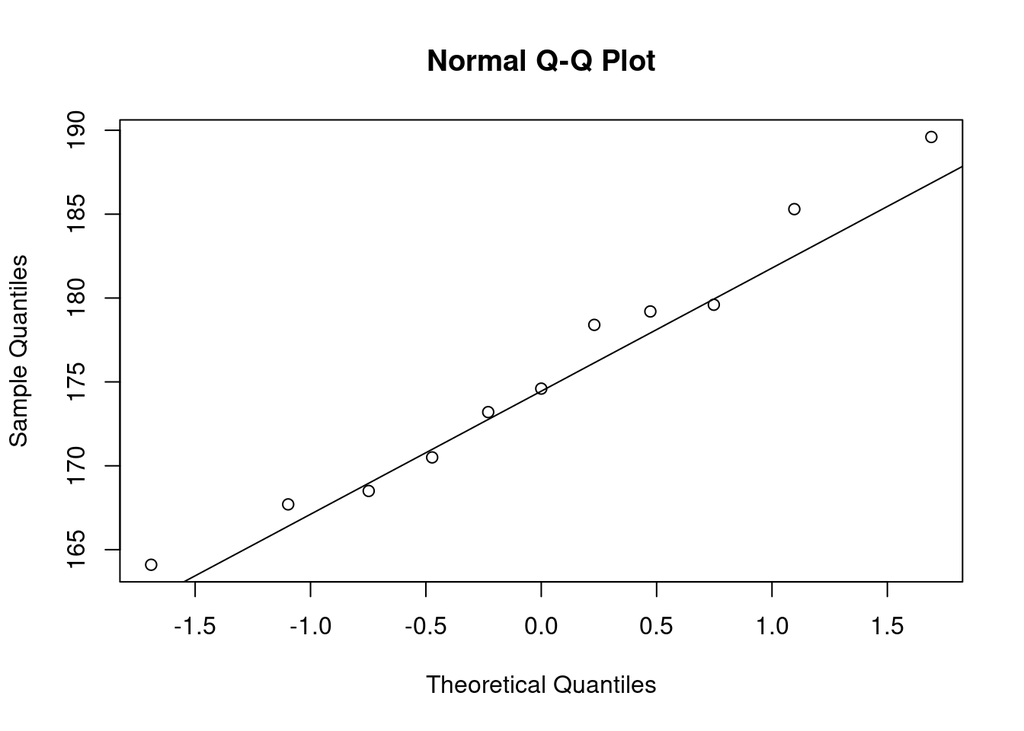

```r
qqnorm(x)
qqline(x)
```

## Två teoriuppgifter

1. Om en exponentialfördelad slumpvariabel har väntevärde a, har den också standardavvikelse a.
2. Den stokatiska variabeln X är likformigt fördelad med väntevärde a. Vi vet att om X är Re(p,q)-fördelad, så är väntevärdet E(X)=(p+q)/2. Vi vet också att variansen är V(X)=(q-p)^2/12 och standardavvikelsen är D(X)=(q-p)/12^(1/2). Vi söker nu p och q (dvs fördelningens övre och undre gränser), uttryckt i a, så att V(X)=D(X). Jag räknade detta i mitt block och kom fram till att den undre gränsen är a-sqrt(3) och den övre är a+sqrt(3). Detta ger att både variansen och standardavvikelsen blir 1. Vi har även den triviala lösningen där varians och std är 0, vilket fås genom att sätta båda gränserna till a.

# Kan data anses vara normalfördelad?

Ofta ställs man som statistiker inför ovanstående fråga. Vi ska här jämföra olika (framför allt grafiska) metoder som kan användas för att besvara den. Vi ska också försöka besvara frågan om hur stort vårt n (antal observationer i vårt stickprov från en okänd sannolikhetsfördelning) behöver vara, för att vi ska kunna avgöra om stickprovet är normalfördelat eller ej. Detta ska vi ta reda på genom att simulera data från för oss kända fördelningar, både normalfördelade och icke-normalfördelade data. “Alla fördelningar som ni ska jämföra ska ha väntevärde och standardavvikelse lika med a, där a är de två sista siffrorna i erat personnummer (om ni jobbar i par, välj den enas personnummer att jobba med).”

## Frågor till uppgiften

1. Vilken är det *minsta stickprovsstorleken* som behövs för att den *fördelning* ni simulerar från skall avslöja sig som normal eller icke-normal?
2. Vilken grafisk metod anser ni är *mest effektiv* för att avgöra om ett stickprov är normalfördelat eller inte? Motivera med de olika grafiska metoderna (boxplot, histogram, normalfördelningsplott).

## “Uppgift 2.1: Normalfördelade data”

Vi simulerar ett stickprov om 10 observationer från normalfördelad data:

```r
set.seed(19960120)
x1 <- rnorm(10, 24, 24) # antal simulerade värden, väntevärde, standardavvikelse
```

Vi jämför slumptalen som vi precis simulerade, med den sanna normalfördelningen:

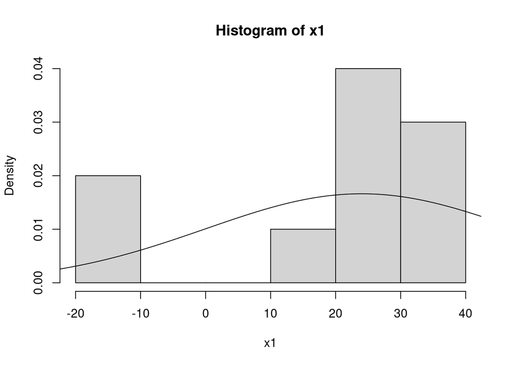

```r
hist(x1, prob = TRUE)
x <- seq(from = -24, to = 72, length.out = 100)
lines(x, dnorm(x, 24, 24))
```

Vi betraktar stickprovet med hjälp av en boxplot:

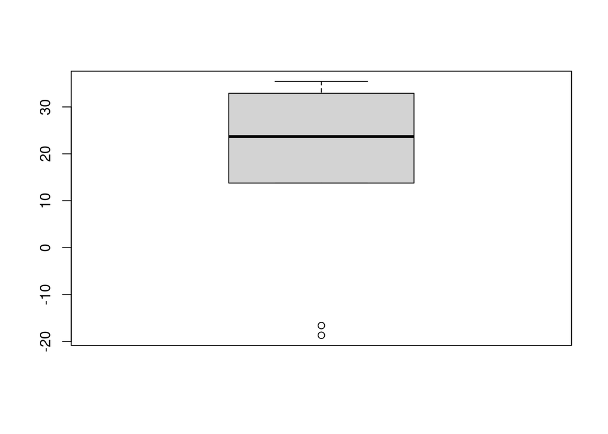

```r
boxplot(x1)
```

Och en normalfördelningsplot:

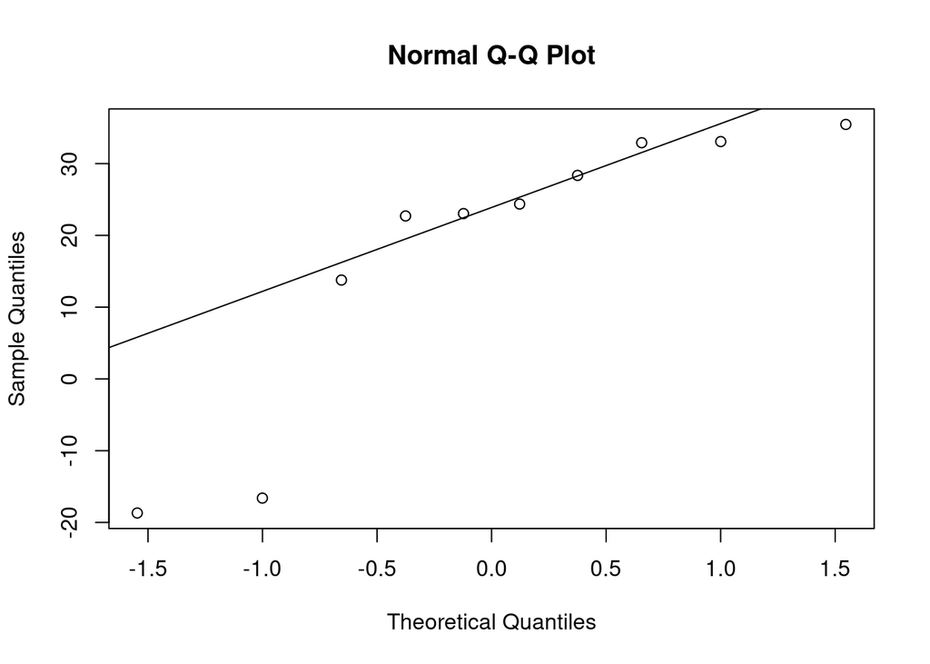

```r
qqnorm(x1)
qqline(x1)
```

```r
set.seed(19960120)
x1 <- rnorm(100, 24, 24) # Detta är samma som ovan pga set.seed
x2 <- rnorm(100, 24, 24) # Detta blir nya slumptal
x3 <- rnorm(100, 24, 24) # Osv
x4 <- rnorm(100, 24, 24)
x5 <- rnorm(100, 24, 24)
x6 <- rnorm(100, 24, 24)
x7 <- rnorm(100, 24, 24)
x8 <- rnorm(100, 24, 24)
```

Vi betraktar ovanstående åtta stickprov i en gemensam boxplot, för att få en överblick över dem:

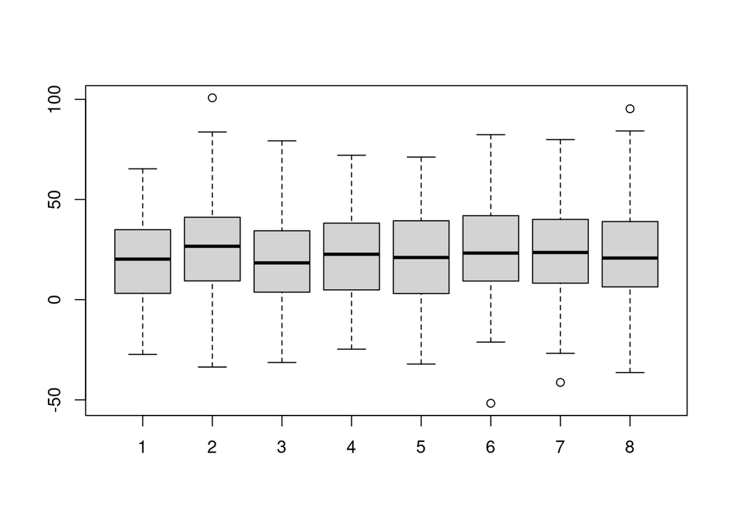

```r
boxplot(x1, x2, x3, x4, x5, x6, x7, x8)
```

Nu vill vi titta på stickproven i form av histogram:

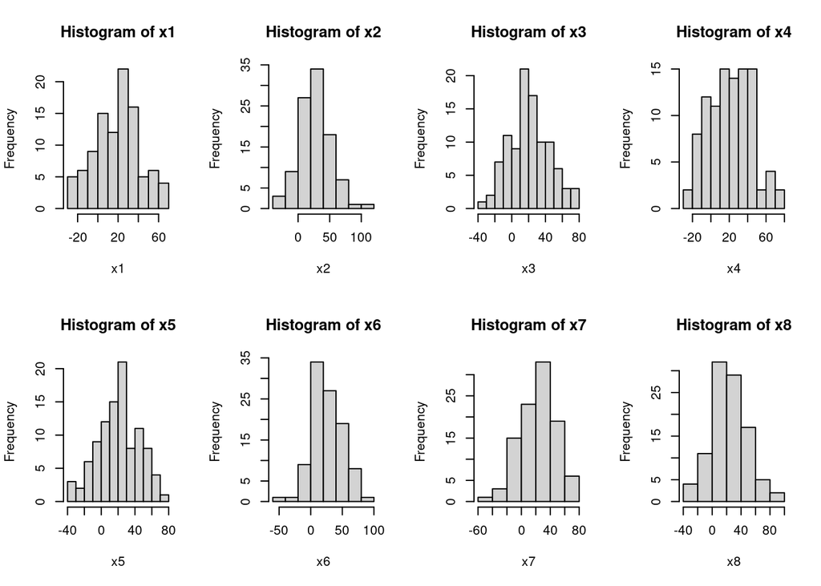

```r
old_par <- par(mfrow = c(2, 4)) # 2 rader, 4 kolumner
hist(x1)
hist(x2)
hist(x3)
hist(x4)
hist(x5)
hist(x6)
hist(x7)
hist(x8)
```

```r
par(old_par) # "Säg åt R att sluta förvänta sig fler plottar till samma fönster"
```

Ohc nu i form av normalfördelningsplottar:

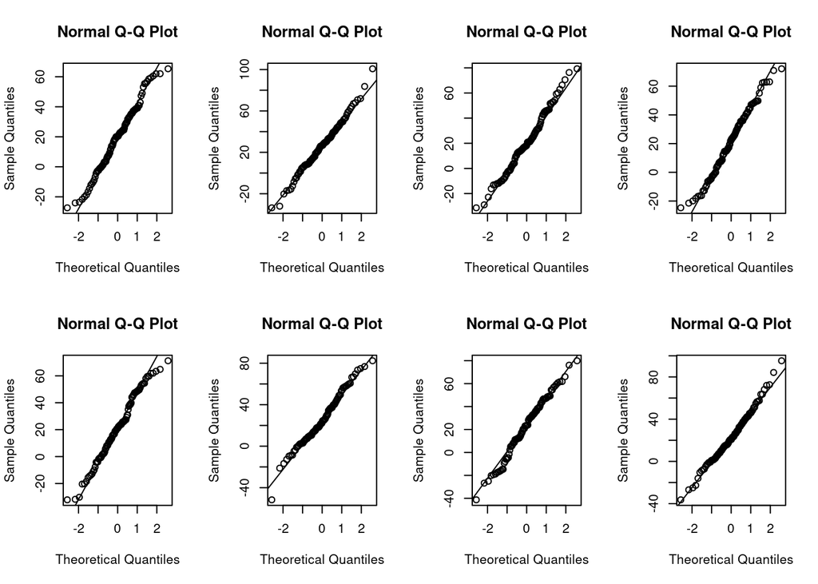

```r
old_par <- par(mfrow = c(2, 4)) # 2 rader, 4 kolumner
qqnorm(x1)
qqline(x1)
qqnorm(x2)
qqline(x2)
qqnorm(x3)
qqline(x3)
qqnorm(x4)
qqline(x4)
qqnorm(x5)
qqline(x5)
qqnorm(x6)
qqline(x6)
qqnorm(x7)
qqline(x7)
qqnorm(x8)
qqline(x8)
```

## “Uppgift 2.2: Likformigt fördelade data”

```r
set.seed(19960120)
u1 <- runif(100, 24-sqrt(3), 24+sqrt(3)) # antal simulerade värden, min, max
u2 <- runif(100, 24-sqrt(3), 24+sqrt(3))
u3 <- runif(100, 24-sqrt(3), 24+sqrt(3))
u4 <- runif(100, 24-sqrt(3), 24+sqrt(3))
u5 <- runif(100, 24-sqrt(3), 24+sqrt(3))
```

Vi jämför stickproven i en boxplot:

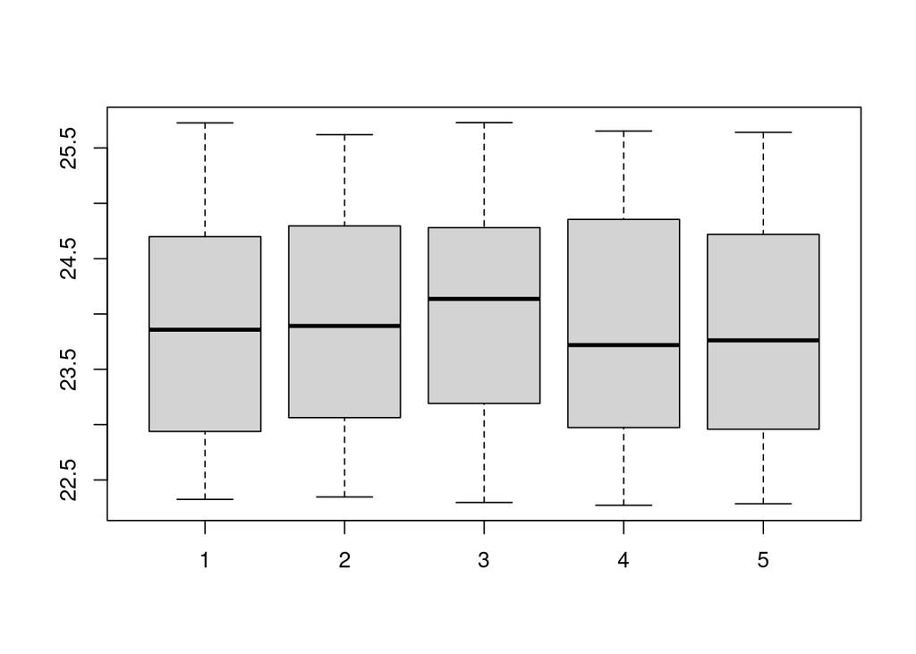

```r
boxplot(u1, u2, u3, u4, u5)
```

Och i histogram:

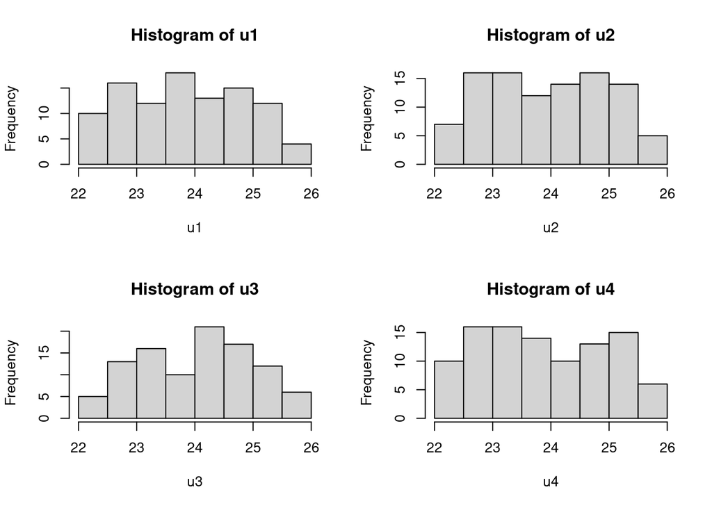

```r
old_par <- par(mfrow = c(2, 2)) # 2 rader, 4 kolumner
hist(u1)
hist(u2)
hist(u3)
hist(u4)
```

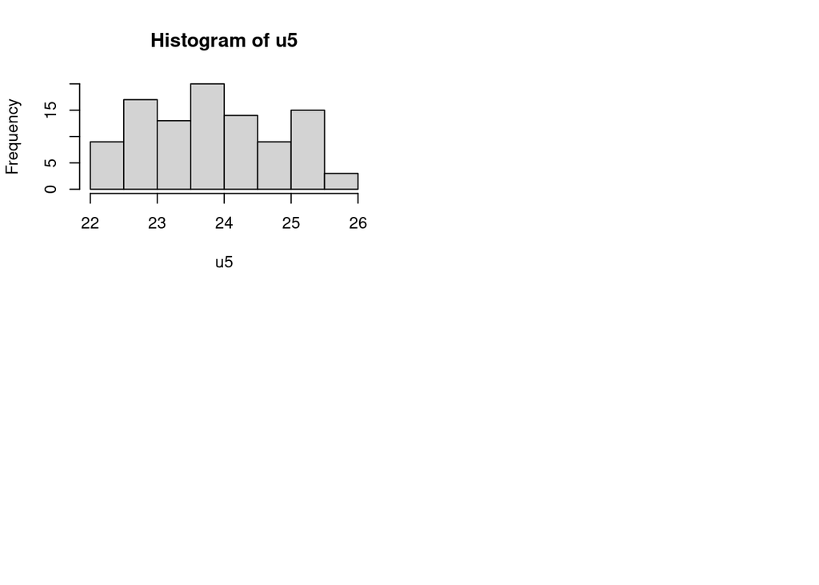

```r
hist(u5)
par(old_par) # "Säg åt R att sluta förvänta sig fler plottar till samma fönster"
```

Och i normalfördelningsplot:

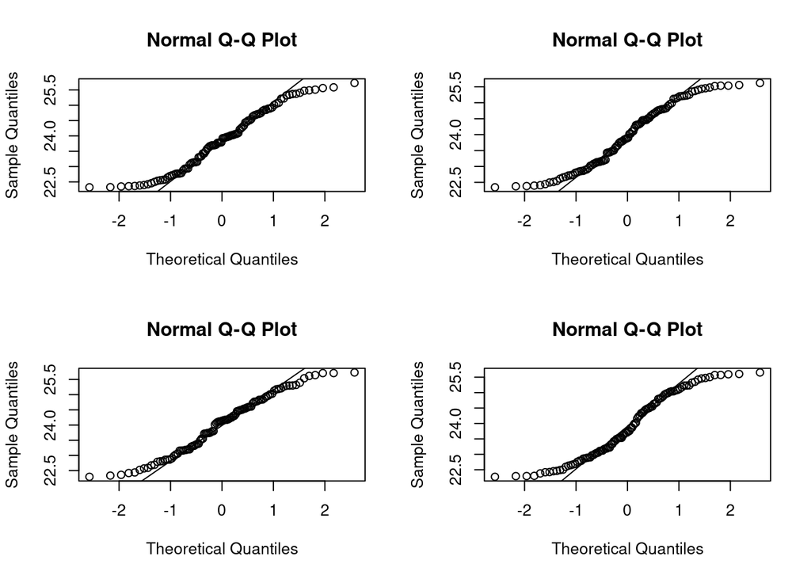

```r
old_par <- par(mfrow = c(2, 2)) # 2 rader, 4 kolumner
qqnorm(u1)
qqline(u1)
qqnorm(u2)
qqline(u2)
qqnorm(u3)
qqline(u3)
qqnorm(u4)
qqline(u4)
```

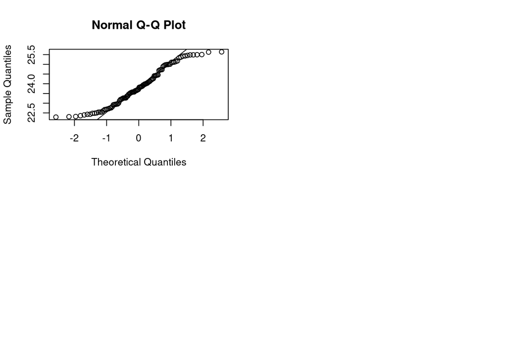

```r
qqnorm(u5)
qqline(u5)
```

Låt oss jämföra stickproven från den normalfördelade datan med stickproven från den likformigt fördelade datan.

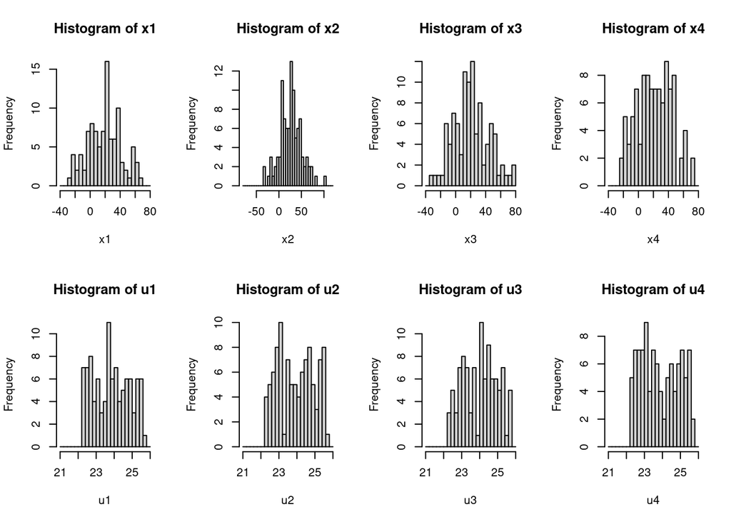

```r
old_par <- par(mfrow = c(2, 4))
hist(x1, breaks = seq(from = -40, to = 80, by = 5))
hist(x2, breaks = seq(from = -80, to = 120, by = 5))
hist(x3, breaks = seq(from = -40, to = 80, by = 5))
hist(x4, breaks = seq(from = -40, to = 80, by = 5))
hist(u1, breaks = seq(from = 21, to = 26, by = 0.2))
hist(u2, breaks = seq(from = 21, to = 26, by = 0.2))
hist(u3, breaks = seq(from = 21, to = 26, by = 0.2))
hist(u4, breaks = seq(from = 21, to = 26, by = 0.2))
```

Upprepa er analys med stickprovsstorlekarna n = 20, n = 100 och ytterligare något värde på n som ni väljer själva. Besvara sedan frågorna som tidigare ställts:

## Frågor till uppgiften

1. Vilken är det *minsta stickprovsstorleken* som behövs för att den *fördelning* ni simulerar från skall avslöja sig som normal eller icke-normal?
2. Vilken grafisk metod anser ni är *mest effektiv* för att avgöra om ett stickprov är normalfördelat eller inte? Motivera med de olika grafiska metoderna (boxplot, histogram, normalfördelningsplott).

Vad gäller val av metod vill jag förespråka normalfördelningsplotten. Hittills tycker jag att normalfördelningsplotten är den utifrån vilken det tydligast går att med ögat avgöra om data är normalfördelad eller ej. Boxploten tycker jag är den svåraste. Histogrammet är okej men för t.ex. n=100 ser man mycket tydligare skillnad mellan stickproven från den likformiga fördelnignen och den normalfördelade i normalfördelningsplotten än i histogrammen.

Vad gäller storlek på stickprovet tycker jag att det är svårare. Framför allt beror storleken på stickprovet på val av metod! T.ex. tycker jag att det inte krävs lika många observationer för att kunna avgöra normal/icke-normal i en normalfördelningsplot, som i ett histogram. (Vi får simulera och testa oss fram för att komma fram till ett gränsvärde för n!)

## “Uppgift 2.3: Exponentialfördelade data”

Dags att undersöka samma sak för stickprov från exponentialfördelade data. Vi skapar våra stickprov:

```r
set.seed(19960120)
e1 <- rexp(20, 1/24) # antal simulerade observationer, 1/väntevärdet
e2 <- rexp(20, 1/24)
e3 <- rexp(20, 1/24)
e4 <- rexp(20, 1/24)
e5 <- rexp(20, 1/24)
e6 <- rexp(20, 1/24)
```

Vi visualiserar i en boxplot:

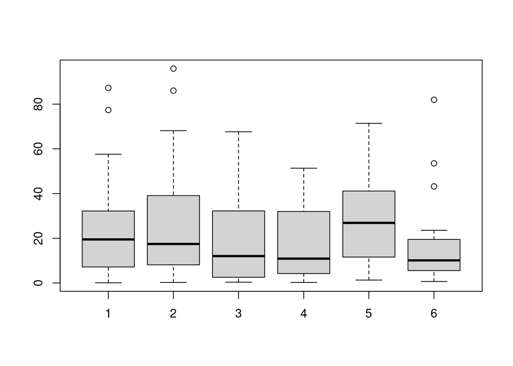

```r
boxplot(e1, e2, e3, e4, e5, e6)
```

Låt oss titta på stickproven i histogram:

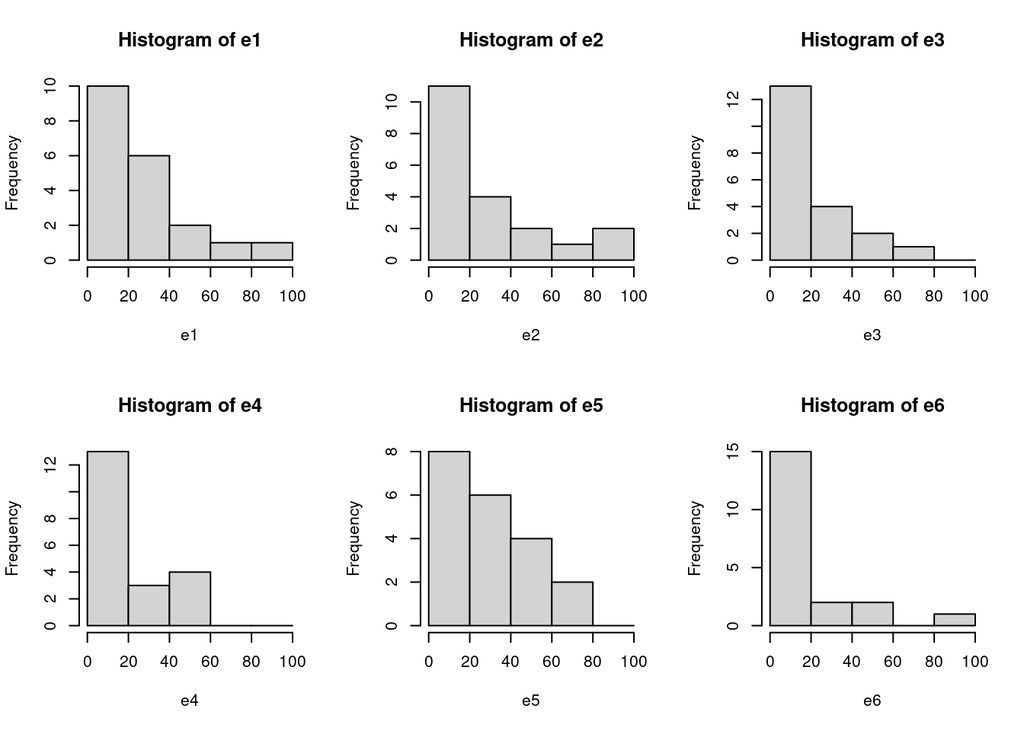

```r
old_par <- par(mfrow = c(2, 3))
hist(e1, breaks = seq(from = 0, to = 100, by = 20))
hist(e2, breaks = seq(from = 0, to = 100, by = 20))
hist(e3, breaks = seq(from = 0, to = 100, by = 20))
hist(e4, breaks = seq(from = 0, to = 100, by = 20))
hist(e5, breaks = seq(from = 0, to = 100, by = 20))
hist(e6, breaks = seq(from = 0, to = 100, by = 20))
```

Den tredje och sista typen av visualisering: Normalfördelningsplotten! Let’s go.

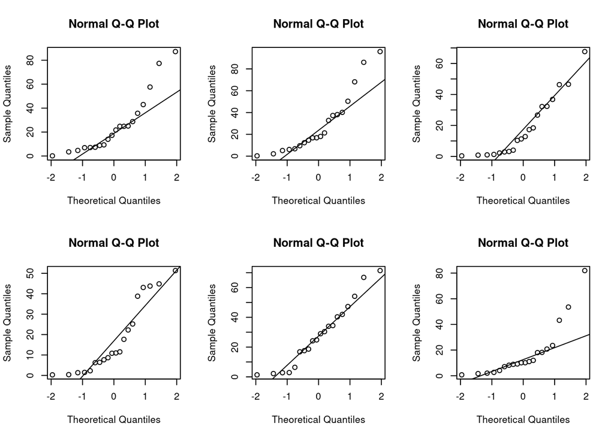

```r
old_par <- par(mfrow = c(2, 3))
qqnorm(e1)
qqline(e1)
qqnorm(e2)
qqline(e2)
qqnorm(e3)
qqline(e3)
qqnorm(e4)
qqline(e4)
qqnorm(e5)
qqline(e5)
qqnorm(e6)
qqline(e6)
```

Jag tycker faktiskt att även n=20 ger tvetydiga resultat i normalfördelningsplotten. När vi tittar på ett större antal stickprov (i det här fallet 6 stickprov) så blir jag (kanske) övertygad om att det inte är normalfördelade data. Men inte helt. Intressant!!!

# “Uppgift 3: Explorativ dataanalys”

```r
alc <- read.csv("olvinsprit.csv", header = TRUE)
alc
```

```
##              Land beer vin sprit
## 1         Sverige   56  16   2.9
## 2         Danmark   98  32   2.7
## 3         Finland   79  10   5.7
## 4           Norge   56  11   2.4
## 5         Belgien   98  30   2.6
## 6       Frankrike   41  47   7.2
## 7          Irland  155  13   5.3
## 8         Italien   29  54   2.7
## 9         Holland   80  20   4.7
## 10        Schweiz   57  42   2.4
## 11 Storbritannien   97  20   3.9
## 12       Tyskland  119  26   5.3
## 13      Osterrike  106  36   3.2
## 14            USA   85   7   4.8
## 15         Kanada   70  10   4.3
## 16     Australien   89  21   2.6
## 17    Nya_Zeeland   78  19   2.3
## 18          Japan   55  10   8.2
```

```r
land <- alc$Land
beer <- alc$beer
vin <- alc$vin
sprit <- alc$sprit
```

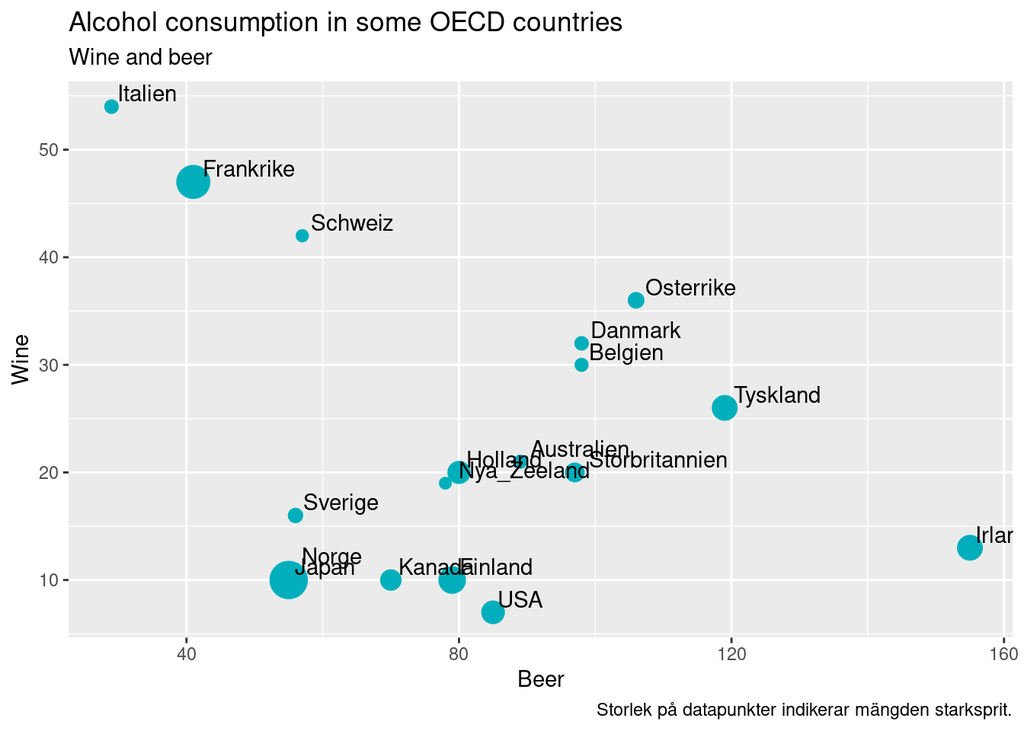

```r
gg_alc <- ggplot(alc, aes(x=beer, y=vin, label=Land)) +
  geom_point(col = "#00AFBB", size = sprit) +
  geom_text(hjust=-0.1, vjust=-0.3) +
  labs(title="Alcohol consumption in some OECD countries",
       subtitle="Wine and beer",
       y="Wine",
       x="Beer",
       caption="Storlek på datapunkter indikerar mängden starksprit.")
plot(gg_alc)
```

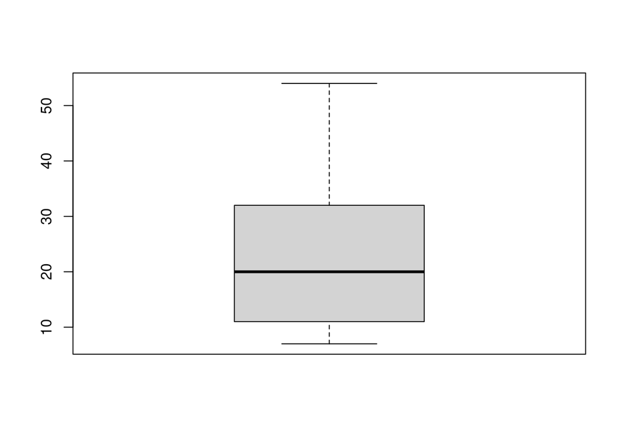

```r
boxplot(alc$vin)
```

—–REDOVISNING—–

# Sammanfattning

# Uppgift 1

# Uppgift 2